# Reconstructing network in randomized vs non-randomized data

## Intro

First attempt in analyzing the effect of randomization on network reconstruction. We start studying what happens to the correlation matrix and then what happens to the output of methods based on partial correlations

## Starting the analysis

Let’s set up the analysis:

```r
#cleaning memory
rm(list =ls())

#set seed
set.seed(12345)

#libraries
if(!require(flowCore)){
  install.packages('flowcore')
  require(flowCore)
}
if(!require(huge)){
  install.packages('huge')
  require(huge)
}

#number of samples to select randomly; set to NA to retain all samples
nSamples <- NA

#actual names
aNames <- read.csv('../../Data/markers.csv', header = TRUE, stringsAsFactors = FALSE)
aNames$CytkPanel <- NULL; #this is a phos panel

#columns to eliminate
#toEliminate <- c('Time', 'Event_length', 'Pd102Di', 'Pd104Di', 'Pd105Di', 'Pd106Di', 'Pd108Di', 'Pd110Di', 'Ce140Di', 'Ir191Di', 'Ir193Di')
markersToEliminate <- as.numeric(unlist(sapply(c("Barcode", "Time", "cell length", "unkn", "EQBeads", "DNA", "TCRab", "\\bCD4\\b", "ICOS", "CCR6", "CD57", "CD28"),grep, aNames$PhosPanel)))
markersToKeep <- aNames$channel[setdiff(1:length(aNames$PhosPanel), markersToEliminate)]
newMarkerNames <- aNames$PhosPanel[setdiff(1:length(aNames$PhosPanel), markersToEliminate)]

# allMarkers <- read.csv(paste0(dataFolder,'markers.csv'),stringsAsFactors = F)

##
## Exclude non Marker and failed Marker variables
##

# nonMarkers.Cytk <- as.numeric(unlist(sapply(c("Barcode","Time","cell length","unkn","EQBeads","DNA"),grep, allMarkers$CytkPanel)))

# failedMarkers <- as.numeric(unlist(sapply(c("TCRab", "\\bCD4\\b", "ICOS", "CCR6", "CD57", "CD28"),grep, allMarkers$PhosPanel)))
```

```r
#loading data
nonRandom <- read.FCS('../../Data/gated data/2390__EXP-17-BY9239__internal__Donor A (Schmidt project)__Stim_2min_wo PI__1.fcs')

#matrix of measurements
nonRandom <- exprs(nonRandom)

#eliminating columns related to technical measurements
nonRandom <- nonRandom[ , markersToKeep]
colnames(nonRandom) <- newMarkerNames;
nVars <- dim(nonRandom)[2]

# transforming with the arcsinh
nonRandom <- asinh(nonRandom/5)

#selecting a sub-sample
if(!is.na(nSamples)){
  zz = sample.int(dim(nonRandom)[1], nSamples)
  nonRandom <- nonRandom[zz, ]
}
```

We perform the first steps also for the randomized data, taking care of selecting the same sub-sample we selected for the non-randomized ones

```r
#reading data
random <- read.FCS('../../Data/gated_randomized/2390__Donor A__Stim_2min_wo PI__1.fcs')

#measurement matrix
random <- exprs(random)

#selecting columns and sub-sample
random <- random[ , markersToKeep]
colnames(random) <- newMarkerNames
if(!is.na(nSamples)){
  random <- random[zz, ]
}
```

## Correlations matrices

Let’s compute the correlation matrices for both datasets and let’s compare them.

```r
#correlation matrices
nonRandomCor <- cor(nonRandom)
randomCor <- cor(random)

#difference between unique values (upper matrix excluding the diagonal)
idx <- upper.tri(nonRandomCor, diag = FALSE)
diffCor <- as.numeric(abs(nonRandomCor[idx] - randomCor[idx]))

#exploring the difference
summary(diffCor)
```

```
##      Min.   1st Qu.    Median      Mean   3rd Qu.      Max.
## 2.686e-05 8.400e-03 1.671e-02 2.162e-02 2.717e-02 1.554e-01
```

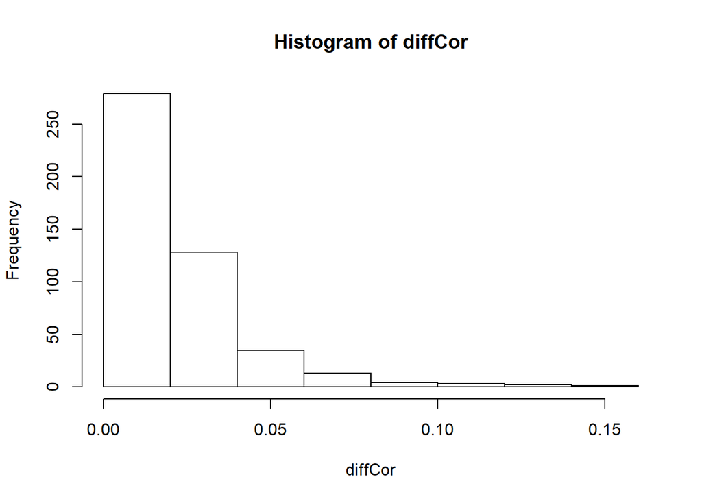

```r
hist(diffCor)
```

We see that the difference is relatively low on average (0.0216), however there are some more massive differences (up to 0.1554)

## Using glasso

The funny part now! We use the Graphical Lasso method for computing a partial-correlation graph on the non-randomized data

```r
#applying the glasso method
nonRandomRes <- huge(nonRandom, method = 'glasso')
nonRandomRes <- huge.select(nonRandomRes)
nonRandomGraph <- as.matrix(nonRandomRes$refit)
```

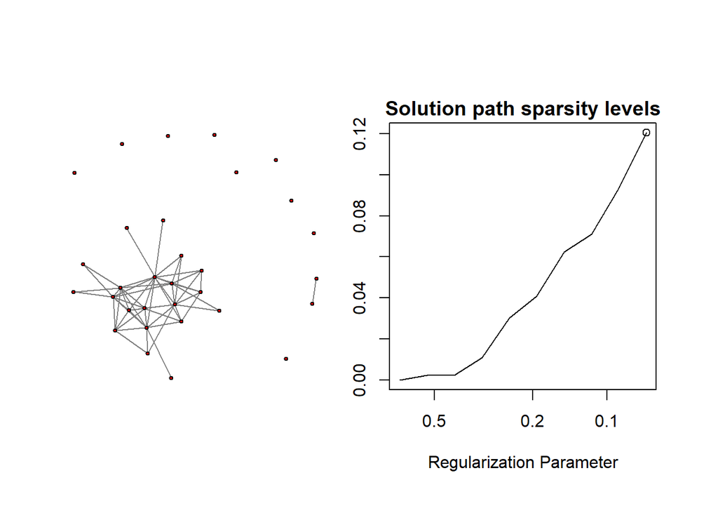

```r
#plotting the results
plot(nonRandomRes)
```

We do the same on the randomized data

```r
#applying the glasso method
randomRes <- huge(random, method = 'glasso')
randomRes <- huge.select(randomRes)
randomGraph <- as.matrix(randomRes$refit)
```

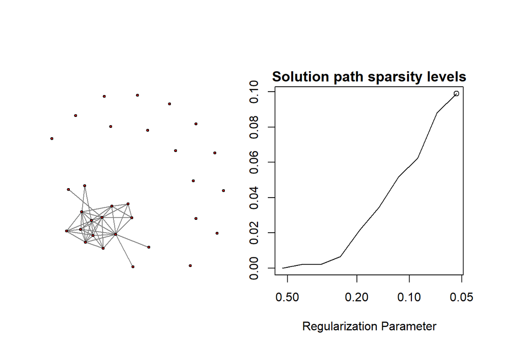

```r
#plotting the results
plot(randomRes)
```

And now we compare the two outputs. The network on the non-randomized data has 112 edges, while other network has 92 edges, for a total difference of 28. Let’s dissect this difference even more:

Number of edges in the non-randomized data network that are not in the other network: 24

Number of edges in the randomized data network that are not in the other network: 4

Question: do these differences correspond to correlations greatly altered by the randomization?

```r
#selecting the differences corresponding to changes in the graphs
selectedDiffCor <- diffCor[nonRandomGraph[idx] != randomGraph[idx]]

#selecting the differences corresponding to edges that are identical in the two graphs
otherDiffCor <- diffCor[nonRandomGraph[idx] == randomGraph[idx]]

#t test
t.test(x = selectedDiffCor, y = otherDiffCor)
```

```
##
##  Welch Two Sample t-test
##
## data:  selectedDiffCor and otherDiffCor
## t = 7.3323, df = 15.264, p-value = 2.233e-06
## alternative hypothesis: true difference in means is not equal to 0
## 95 percent confidence interval:
##  0.01754270 0.03189128
## sample estimates:
##  mean of x  mean of y
## 0.04559200 0.02087501
```

Indeed, the differences in the graphs corresponds to cells in the correlation matrices particularly affected by the randomization.

## Using glasso with a fixed lambda

There could be the case that the number of differences in the graph is inflated by a different choice of the hyper-parameter lambda. Indeed, for the non-randomized data the `huge.select()` function indicates 0.0692 as best lambda value, while 0.0537 is the best lambda value for the randomized dataset. We will now re-compute the graphs using an average lambda of 0.0614.

```r
#applying the glasso method with fixed lambda
averageLambda <- mean(c(nonRandomRes$opt.lambda, randomRes$opt.lambda));
nonRandomResFixed <- huge(nonRandom, method = 'glasso', lambda = averageLambda)
nonRandomGraphFixed <- as.matrix(nonRandomResFixed$path[[1]])
randomResFixed <- huge(random, method = 'glasso', lambda = averageLambda)
randomGraphFixed <- as.matrix(randomResFixed$path[[1]])
```

And now we compare again the two outputs. The network on the non-randomized data has 128 edges, while other network has 86 edges, for a total difference of 46. Let’s dissect this difference even more:

Number of edges in the non-randomized data network that are not in the other network: 44

Number of edges in the randomized data network that are not in the other network: 2

With the same lambda the differences are even more evident.